# Chapter 23: Applications of Inference

# Overview

- 23.1 Recap: Computational methods
  - 23.1.1 Randomization
  - 23.1.2 Bootstrapping
- 23.2 Recap: Mathematical models
  - 23.2.1 z-procedures
  - 23.2.2 t-procedures
- 23.3 Case study: Redundant adjectives
  - 23.3.1 Exploratory analysis
  - 23.3.2 Confidence interval for a single mean
  - 23.3.3 Paired mean test
  - 23.3.4 Two independent means test

# 23.1 Recap: Computational methods

- Two types of inference for *an unknown parameter*.
  - Hypothesis Tests
    - Assume $H_0$ about your parameter, and assess how extreme your observed statistic would be.
    - Extreme statistics (low P-values) indicate evidence against $H_0$ in favor of $H_A$.
  - Confidence intervals
    - Measure the observed statistic, and compute a margin of error.
    - The confidence interval represents a range of plausible values for the unknown parameter.

## 23.1.1 Randomization (Hypothesis Tests)

- Write appropriate hypotheses.
- Compute the observed statistic of interest.
- Permute the data repeatedly, each time, recalculating the statistic of interest.
- Compute the proportion of times the permuted statistics are as extreme as or more extreme than the observed statistic, this is the p-value.
- Make a conclusion based on the p-value, and write the conclusion in context and in plain language so anyone can understand the result.

## 23.1.2 Bootstrapping (Confidence Intervals)

- Repeatedly resample the original data, with replacement, using the same sample size as the original data.
- For each resample, calculate the statistic of interest.
- Calculate the confidence interval using one of the following methods:
  - Bootstrap percentile interval: Obtain the endpoints representing the middle (e.g., 95%) of the bootstrapped statistics.
  - Bootstrap standard error (SE) interval: Find the SE of the bootstrapped statistics. The confidence interval will be the observed statistic plus or minus some multiple (e.g., 2) of SEs.
- Put the conclusions in context and in plain language so even non-statisticians can understand the results.

# 23.2 Recap: Mathematical models

| Response | Explanatory | Model |
| --- | --- | --- |
| Categorical | none | One-proportion z-test |
| Categorical (2 levels) | Categorical (2 levels) | Two-proportion z-test |
| Categorical ($\geq$ 2 levels) | Categorical ($\geq$ 2 levels) | Chi-squared |
| Numerical | none | One-sample t-test |
| Numerical | Categorical (2 levels) | Two-sample t-test |
| Numerical | Categorical (2 levels, paired) | Paired t-test |
| Numerical | Categorical ($\geq$ 2 levels) | ANOVA F-test |

## Group Activity

For each study description, choose the appropriate scenario/model. At least one person from each group should complete the following Google Form:

https://forms.gle/ibCCkVJrt6EubG4b9

# 23.3 Case study: Redundant adjectives

- What factors affect whether people use “redundant adjectives”?
  - Context
  - Native Language
- Experiment: show two images to 22 native English speakers (undergraduates from University College London) and 22 native Spanish speakers (undergraduates from the Universidad de las Islas Baleares).

## 23.3.1 Exploratory analysis

```r
glimpse(redundant)
```

```
Rows: 88
Columns: 5
$ Language       <chr> "English", "English", "English", "English", "English", "English", "English"…
$ Subject        <dbl> 1, 1, 2, 2, 3, 3, 4, 4, 5, 5, 6, 6, 7, 7, 8, 8, 9, 9, 10, 10, 11, 11, 12, 1…
$ items          <fct> 4, 16, 4, 16, 4, 16, 4, 16, 4, 16, 4, 16, 4, 16, 4, 16, 4, 16, 4, 16, 4, 16…
$ n_questions    <int> 10, 10, 10, 10, 10, 10, 10, 10, 10, 10, 10, 10, 10, 10, 10, 10, 10, 10, 10,…
$ redundant_perc <dbl> 100, 100, 0, 0, 100, 100, 10, 80, 0, 90, 0, 70, 100, 100, 0, 100, 0, 100, 0…
```

## Redundant adjectives: boxplots

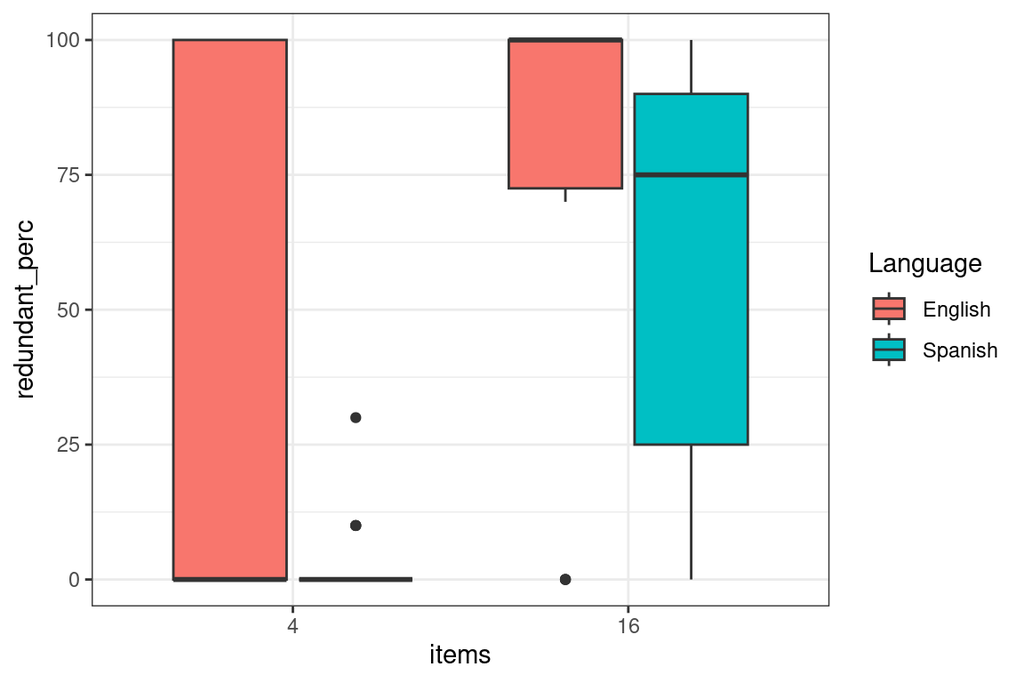

```r
ggplot(redundant, aes(x = items, y = redundant_perc, fill = Language)) + geom_boxplot()
```

## Redundant adjectives: violin plots

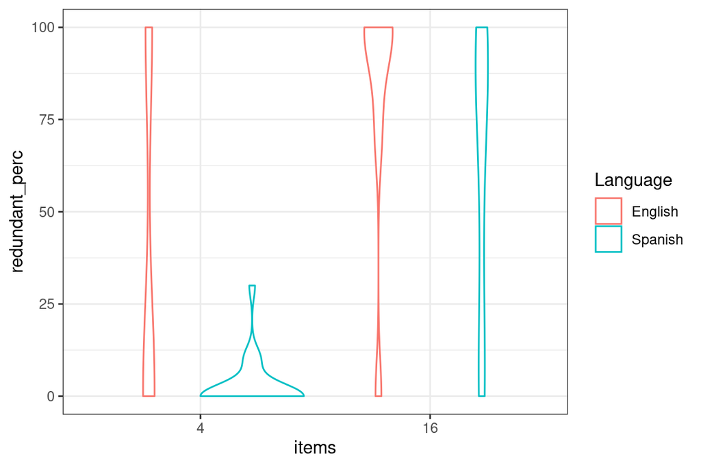

```r
ggplot(redundant, aes(x = items, y = redundant_perc, color = Language)) + geom_violin()
```

## 23.3.2 Confidence interval for a single mean

Mean redundant adjective usage: English speakers, 4 items

```r
redundant %>%
  filter(Language == "English",
         items == 4) %>%
  t.test(redundant_perc ~ 1, data = .)
```

```
    One Sample t-test

data:  redundant_perc
t = 3.5959, df = 21, p-value = 0.0017
alternative hypothesis: true mean is not equal to 0
95 percent confidence interval:
 15.71705 58.82841
sample estimates:
mean of x
 37.27273
```

# Group Activty

For each research question, (1) determine the appropriate *scenario*, (2) state *hypotheses* in symbols, and (3) describe the *observed statistic* in words.

- Do the data provide convincing evidence of a difference in mean redundant adjective usage percentages between sparse (4 item) and dense (16 item) displays for English speakers?
- How does redundant adjective usage differ between English speakers and Spanish speakers?

## 23.3.3 Paired mean test

```r
redundant %>%
  filter(Language == "English") %>%
  pivot_wider(names_from = items,
              values_from = redundant_perc,
              names_prefix = "item") %>%
  {t.test(.$item16, .$item4, paired = TRUE)}
```

```
    Paired t-test

data:  .$item16 and .$item4
t = 4.4824, df = 21, p-value = 0.0002051
alternative hypothesis: true mean difference is not equal to 0
95 percent confidence interval:
 23.14747 63.21617
sample estimates:
mean difference
       43.18182
```

## Item comparison (English speakers)

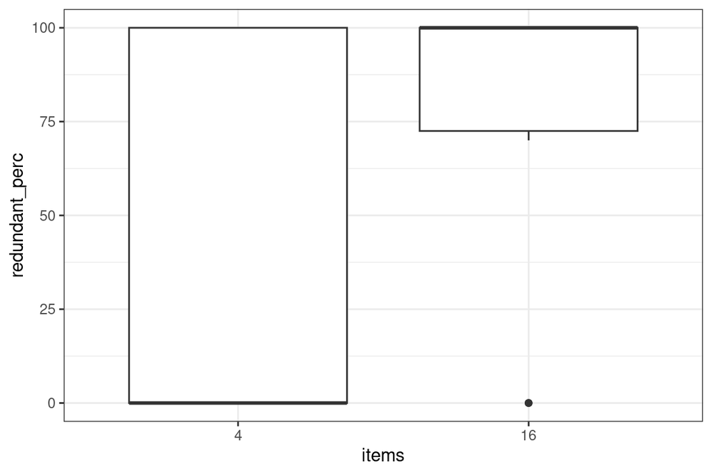

```r
redundant %>%
  filter(Language == "English") %>%
  ggplot(aes(x = items, y = redundant_perc)) +
    geom_boxplot()
```

## Item comparison (English speakers)

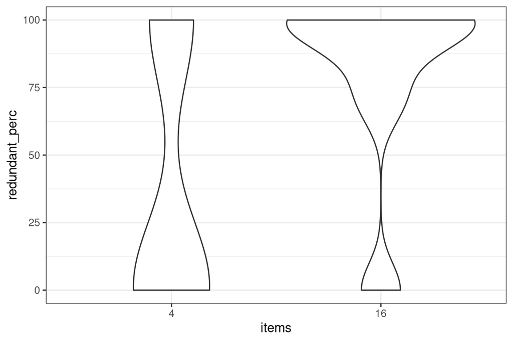

```r
redundant %>%
  filter(Language == "English") %>%
  ggplot(aes(x = items, y = redundant_perc)) +
    geom_violin()
```

## 23.3.4 Two independent means test

## Two mean t-test (4 items)

```r
redundant %>%
  filter(items == 4) %>%
  t.test(redundant_perc ~ Language, data = .)
```

```
    Welch Two Sample t-test

data:  redundant_perc by Language
t = 3.2986, df = 21.877, p-value = 0.003291
alternative hypothesis: true difference in means between group English and group Spanish is not equal to 0
95 percent confidence interval:
 12.81892 56.27199
sample estimates:
mean in group English mean in group Spanish
            37.272727              2.727273
```

## Two mean t-test (16 items)

```r
redundant %>%
  filter(items == 16) %>%
  t.test(redundant_perc ~ Language, data = .)
```

```
    Welch Two Sample t-test

data:  redundant_perc by Language
t = 1.7134, df = 41.282, p-value = 0.09414
alternative hypothesis: true difference in means between group English and group Spanish is not equal to 0
95 percent confidence interval:
 -3.406137 41.587955
sample estimates:
mean in group English mean in group Spanish
             80.45455              61.36364
```

## English vs. Spanish (4 items)

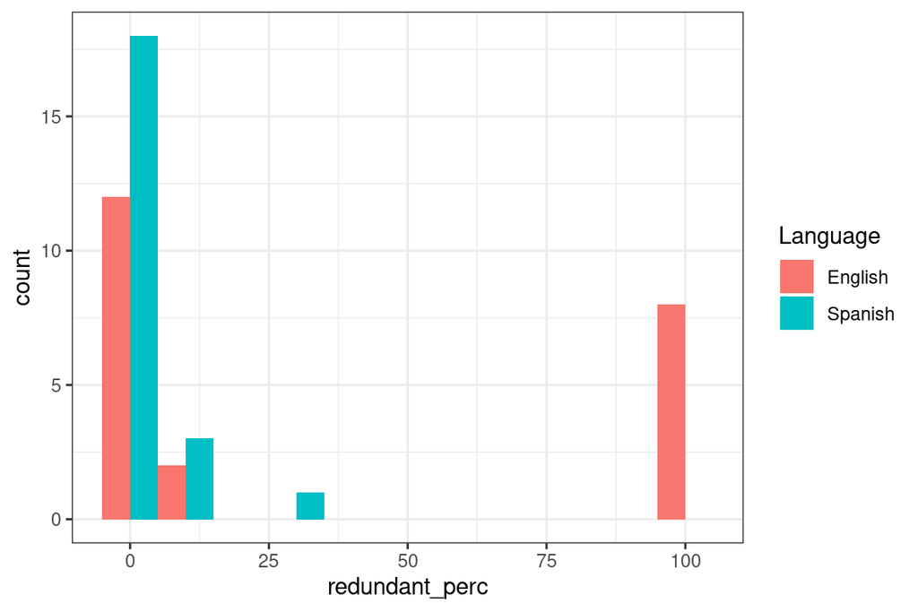

```r
redundant %>%
  filter(items == 4) %>%
  ggplot(aes(x = redundant_perc, fill = Language)) +
    geom_histogram(binwidth = 10, position = "dodge")
```

## English vs. Spanish (16 items)

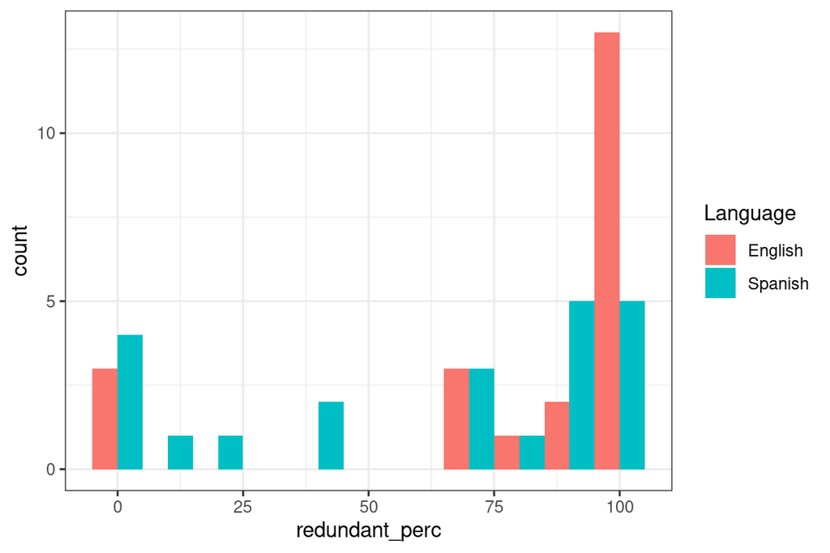

```r
redundant %>%
  filter(items == 16) %>%
  ggplot(aes(x = redundant_perc, fill = Language)) +
    geom_histogram(binwidth = 10, position = "dodge")
```